# Native Hawaiian and Pacific Islander Veterans Health Status Report 2024

Cross-sectional Comparison of NHPI Veterans vs. Non-NHPI Veterans who received VA Care in 2024

Author

The Center for Pacific Islander Veteran Health

Published

June 24, 2025

## 1 CPIVH

[figure not shown]

## 3 Objectives

This report aims to:

1. Characterize the prevalence and severity of chronic diseases (diabetes, chronic kidney disease, hypertension, cardiovascular disease, obesity, gout, cancer, and chronic neurological disease) and those specifically relevant to Veteran populations (alzheimer’s and dementia, TBI/CTE, PTSD, cognitive impairment, substance abuse, and visual impairment) among NHPI Veterans.
2. Compare disease condition prevalence and severity between NHPI Veterans and Non-NHPI Veterans as well as among NHPI subgroups.

## 4 Methods

- Study Design and Population

Retrospective cross-sectional analysis using a dataset derived from the VA corporate data warehouse (CDW), including EHR and community care claims data. NHPI Veterans were identified using VA race/ethnicity indicators and NLP-extracted data created by the VA’s Center for Pacific Islander Veteran Health (CPIVH) (Viernes et al. 2025).

- Data Sources

Variables include demographics (age, sex, geographic region), chronic disease indicators (diabetes, chronic kidney disease (CKD), hypertension, cardiovascular disease (CVD), obesity), and VA utilization metrics (observation time in VA, outpatient visit count, inpatient visit count, number of unique diagnoses recorded, number of prescriptions issued, and number of procedure codes recorded).

## 5 Methods cont.

- Statistical Analysis

Analyses include descriptive statistics of conditions across groups using chi-squared and paired t-tests for statistical significance. Additionally, adjusted logistic regression analyses were performed to identify odds of having a specific disease given NHPI or Non-NHPI status.

- Limitations/Caveats

Limited causal relationships can be developed from a cross-sectional analysis. Further the NHPI population used in this analysis is required to have multiple data points that confirm NHPI status. The Non-NHPI population is not, and maybe be biased due to the fact that multiple data points also is correlated with increased utilization and a more accurate health record. Generalizability is limited to Veterans receiving VA care.

## 6 Table 1a: NHPI vs Non-NHPI Demographic Characteristics

NHPI Cohort versus other race using the most sensitive definition of NHPI

|  | Variable | Total (N=5075230) | NHPI (N=76285) | OtherRace (N=4998945) | p value |
| --- | --- | --- | --- | --- | --- |
| 1 | Age (continuous) at visit |  |  |  | &lt; 0.001 |
| 2 | Mean (SD) | 62.0 (16.3) | 57.4 (16.7) | 62.1 (16.2) |  |
| 3 | Sex |  |  |  | &lt; 0.001 |
| 4 | F | 571322 (11.3%) | 11840 (15.5%) | 559482 (11.2%) |  |
| 5 | M | 4503908 (88.7%) | 64445 (84.5%) | 4439463 (88.8%) |  |
| 6 | US Region |  |  |  | &lt; 0.001 |
| 7 | Hawaii and Pacific | 27930 (0.6%) | 8724 (11.4%) | 19206 (0.4%) |  |
| 8 | Midwest | 1015115 (20.0%) | 7415 (9.7%) | 1007700 (20.2%) |  |
| 9 | Northeast | 626495 (12.3%) | 5244 (6.9%) | 621251 (12.4%) |  |
| 10 | South | 2383452 (47.0%) | 30268 (39.7%) | 2353184 (47.1%) |  |

[output cut: 7 more lines]

## 7 Table 1b: NHPI vs Non-NHPI Utilization Characteristics

NHPI Cohort versus other race using the most sensitive definition of NHPI

|  | Variable | Total (N=5075230) | NHPI (N=76285) | OtherRace (N=4998945) | p value |
| --- | --- | --- | --- | --- | --- |
| 61 | Total Days Since First VA Visit |  |  |  | &lt; 0.001 |
| 62 | Mean (SD) | 6107.1 (2312.6) | 6263.0 (2313.4) | 6104.8 (2312.5) |  |
| 63 | Outpatient Encounter Count |  |  |  | &lt; 0.001 |
| 64 | Mean (SD) | 171.3 (199.4) | 215.2 (251.5) | 170.6 (198.4) |  |
| 65 | Inpatient Stay Count |  |  |  | &lt; 0.001 |
| 66 | Mean (SD) | 0.9 (2.9) | 1.3 (4.3) | 0.9 (2.9) |  |
| 67 | Recorded Diagnoses |  |  |  | &lt; 0.001 |
| 68 | Mean (SD) | 352.2 (483.8) | 453.5 (620.5) | 350.7 (481.2) |  |
| 69 | Prescriptions Issued |  |  |  | &lt; 0.001 |
| 70 | Mean (SD) | 145.4 (186.5) | 176.4 (221.0) | 145.0 (185.9) |  |

## 8 Table 1c: NHPI vs Non-NHPI Chronic Condition Characteristics

NHPI Cohort versus other race using the most sensitive definition of NHPI

|  | Variable | Total (N=5075230) | NHPI (N=76285) | OtherRace (N=4998945) | p value |
| --- | --- | --- | --- | --- | --- |
| 19 | Diabetes |  |  |  | &lt; 0.001 |
| 21 | Yes | 1976217 (38.9%) | 32638 (42.8%) | 1943579 (38.9%) |  |
| 22 | Chronic Kidney Disease |  |  |  | 0.008 |
| 24 | Yes | 921251 (18.2%) | 13566 (17.8%) | 907685 (18.2%) |  |
| 25 | Hypertension |  |  |  | &lt; 0.001 |
| 27 | Yes | 4487713 (88.4%) | 65965 (86.5%) | 4421748 (88.5%) |  |
| 28 | Cardiovascular Disease |  |  |  | &lt; 0.001 |
| 30 | Yes | 2212602 (43.6%) | 30102 (39.5%) | 2182500 (43.7%) |  |
| 31 | Overweight/Obesity, BMI&gt;=25 |  |  |  | &lt; 0.001 |
| 33 | Yes | 4065860 (80.1%) | 62333 (81.7%) | 4003527 (80.1%) |  |

[output cut: 4 more lines]

## 9 Table 1d: NHPI vs Non-NHPI Other Condition Characteristics

NHPI Cohort versus other race using the most sensitive definition of NHPI

|  | Variable | Total (N=5075230) | NHPI (N=76285) | OtherRace (N=4998945) | p value |
| --- | --- | --- | --- | --- | --- |
| 40 | Visual Impairment |  |  |  | &lt; 0.001 |
| 42 | Yes | 341055 (6.7%) | 5711 (7.5%) | 335344 (6.7%) |  |
| 43 | Substance Abuse/Dependence |  |  |  | &lt; 0.001 |
| 45 | Yes | 2664940 (52.5%) | 41106 (53.9%) | 2623834 (52.5%) |  |
| 46 | Chronic Neurological Disease |  |  |  | &lt; 0.001 |
| 48 | Yes | 713894 (14.1%) | 12935 (17.0%) | 700959 (14.0%) |  |
| 49 | Alzheimer's Disease and Related Dementias |  |  |  | &lt; 0.001 |
| 51 | Yes | 2227234 (43.9%) | 40487 (53.1%) | 2186747 (43.7%) |  |
| 52 | Traumatic Brain Injury or Chronic Traumatic Encephalopathy |  |  |  | &lt; 0.001 |
| 54 | Yes | 758375 (14.9%) | 14888 (19.5%) | 743487 (14.9%) |  |

[output cut: 4 more lines]

## 10 Geographic Region Analysis

- NHPI Veterans stratified by the following regions as defined by clinic location of cohort entry visit
  - Midwest (ND, SD, NE, KS, IN, MO, IA, OH,WI,MI,MN,IL)
  - Northeast (PA,NH,ME,CT,NJ,RI,NY,VT,MA,DC)
  - South (WV,OK,KY,AL,AR,TN,LA,MS,SC,TX,GA,NC,FL,VA,DE,MD)
  - West (WY,ID,MT,UT,AK,AZ,NV,CO,NM,OR,WA,CA)
  - Hawaii and Pacific (HI,AP,MP,FM,PW,MH,AS,GU)
    - US Territory or Other = Non-Pacific Territories or Non-US locations

## 11 Table 2a: NHPI Demographic Characteristics across US geographic regions

|  | Variable | Total(N=76285) | Hawaii and Pacific(N=8724) | Midwest(N=7415) | Northeast(N=5244) | South (N=30268) | US Territory or Other(N=1326) | West(N=23308) | p value |
| --- | --- | --- | --- | --- | --- | --- | --- | --- | --- |
| 1 | Age (continuous) at visit |  |  |  |  |  |  |  | &lt; 0.001 |
| 2 | Mean (SD) | 57.4 (16.7) | 59.5 (15.6) | 59.7 (17.0) | 59.1 (17.4) | 57.2 (16.3) | 66.3 (16.0) | 55.3 (16.9) |  |
| 3 | Sex |  |  |  |  |  |  |  | &lt; 0.001 |
| 4 | F | 11840 (15.5%) | 964 (11.0%) | 1037 (14.0%) | 789 (15.0%) | 5614 (18.5%) | 89 (6.7%) | 3347 (14.4%) |  |
| 5 | M | 64445 (84.5%) | 7760 (89.0%) | 6378 (86.0%) | 4455 (85.0%) | 24654 (81.5%) | 1237 (93.3%) | 19961 (85.6%) |  |
| 6 | VA Priority Group* |  |  |  |  |  |  |  | &lt; 0.001 |
| 8 | 0% service-connected disability | 3877 (5.1%) | 233 (2.7%) | 605 (8.2%) | 386 (7.4%) | 1661 (5.5%) | 32 (2.4%) | 960 (4.1%) |  |
| 9 | high disability | 51599 (67.7%) | 5817 (66.7%) | 4207 (56.8%) | 3183 (60.8%) | 21304 (70.4%) | 935 (70.5%) | 16153 (69.3%) |  |
| 10 | low-income | 8470 (11.1%) | 881 (10.1%) | 1109 (15.0%) | 797 (15.2%) | 2925 (9.7%) | 211 (15.9%) | 2547 (10.9%) |  |
| 11 | low/moderate disability | 12289 (16.1%) | 1792 (20.5%) | 1491 (20.1%) | 870 (16.6%) | 4354 (14.4%) | 148 (11.2%) | 3634 (15.6%) |  |

## 12 Table 2b: NHPI Utilization Characteristics across US geographic regions

|  | Variable | Total(N=76285) | Hawaii and Pacific(N=8724) | Midwest(N=7415) | Northeast(N=5244) | South (N=30268) | US Territory or Other(N=1326) | West(N=23308) | p value |
| --- | --- | --- | --- | --- | --- | --- | --- | --- | --- |
| 54 | Total Days Since First VA Visit |  |  |  |  |  |  |  | &lt; 0.001 |
| 55 | Mean (SD) | 6263.0 (2313.4) | 6180.5 (2178.4) | 6601.8 (2194.4) | 6636.6 (2269.7) | 6352.7 (2341.3) | 7280.6 (1984.4) | 5925.1 (2336.0) |  |
| 56 | Outpatient Encounter Count |  |  |  |  |  |  |  | &lt; 0.001 |
| 57 | Mean (SD) | 215.2 (251.5) | 151.4 (175.9) | 248.9 (276.3) | 284.0 (351.5) | 229.8 (250.5) | 272.6 (215.3) | 190.7 (234.9) |  |
| 58 | Inpatient Stay Count |  |  |  |  |  |  |  | &lt; 0.001 |
| 59 | Mean (SD) | 1.3 (4.3) | 0.5 (2.0) | 1.7 (4.6) | 1.7 (5.7) | 1.5 (4.7) | 1.5 (3.2) | 1.1 (3.8) |  |
| 60 | Recorded Diagnoses |  |  |  |  |  |  |  | &lt; 0.001 |
| 61 | Mean (SD) | 453.5 (620.5) | 378.2 (479.3) | 537.0 (677.8) | 566.3 (818.6) | 482.5 (640.1) | 525.0 (493.4) | 387.9 (564.4) |  |
| 62 | Prescriptions Issued |  |  |  |  |  |  |  | &lt; 0.001 |
| 63 | Mean (SD) | 176.4 (221.0) | 108.6 (149.9) | 203.0 (232.0) | 221.0 (271.2) | 197.7 (231.0) | 320.7 (308.2) | 147.5 (195.1) |  |

## 14 Table 2d: Other NHPI Condition Characteristics across US geographic regions

|  | Variable | Total(N=76285) | Hawaii and Pacific(N=8724) | Midwest(N=7415) | Northeast(N=5244) | South (N=30268) | US Territory or Other(N=1326) | West(N=23308) | p value |
| --- | --- | --- | --- | --- | --- | --- | --- | --- | --- |
| 33 | Visual Impairment |  |  |  |  |  |  |  | &lt; 0.001 |
| 35 | Yes | 5711 (7.5%) | 562 (6.4%) | 670 (9.0%) | 357 (6.8%) | 2391 (7.9%) | 214 (16.1%) | 1517 (6.5%) |  |
| 36 | Substance Abuse/Dependence |  |  |  |  |  |  |  | &lt; 0.001 |
| 38 | Yes | 41106 (53.9%) | 4698 (53.9%) | 4628 (62.4%) | 3004 (57.3%) | 16809 (55.5%) | 613 (46.2%) | 11354 (48.7%) |  |
| 39 | Chronic Neurological Disease |  |  |  |  |  |  |  | &lt; 0.001 |
| 41 | Yes | 12935 (17.0%) | 1242 (14.2%) | 1521 (20.5%) | 1011 (19.3%) | 5518 (18.2%) | 242 (18.3%) | 3401 (14.6%) |  |
| 42 | Alzheimer's Disease and Related Dementias |  |  |  |  |  |  |  | &lt; 0.001 |
| 44 | Yes | 40487 (53.1%) | 3919 (44.9%) | 4137 (55.8%) | 2971 (56.7%) | 17174 (56.7%) | 784 (59.1%) | 11502 (49.3%) |  |
| 45 | Traumatic Brain Injury or Chronic Traumatic Encephalopathy |  |  |  |  |  |  |  | &lt; 0.001 |
| 47 | Yes | 14888 (19.5%) | 1303 (14.9%) | 1597 (21.5%) | 1147 (21.9%) | 6082 (20.1%) | 268 (20.2%) | 4491 (19.3%) |  |

[output cut: 4 more lines]

## 15 Visualize disease prevalence by US regions and NHPI status

Cancer, CVD, Diabetes, Gout, Hyptertension, and Chronic Kidney Disease

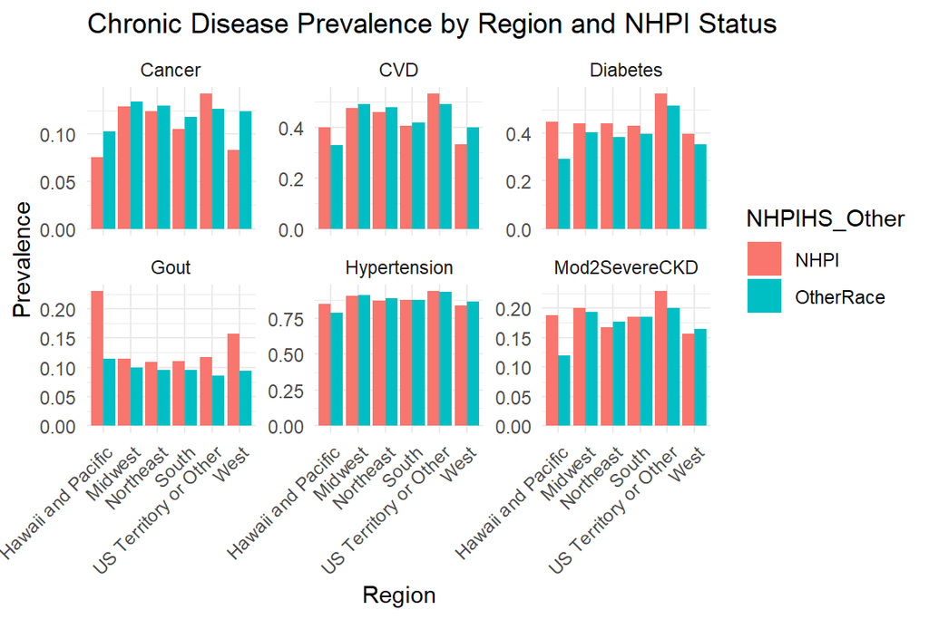

```r
load("P:/ORD_Raphael_202402042D/ChronicDisease/Fig_ChronicCondByRegion2025Jun23.Rdata")
fig1_regionalChr
```

## 16 Visualize disease prevalence by US regions and NHPI status

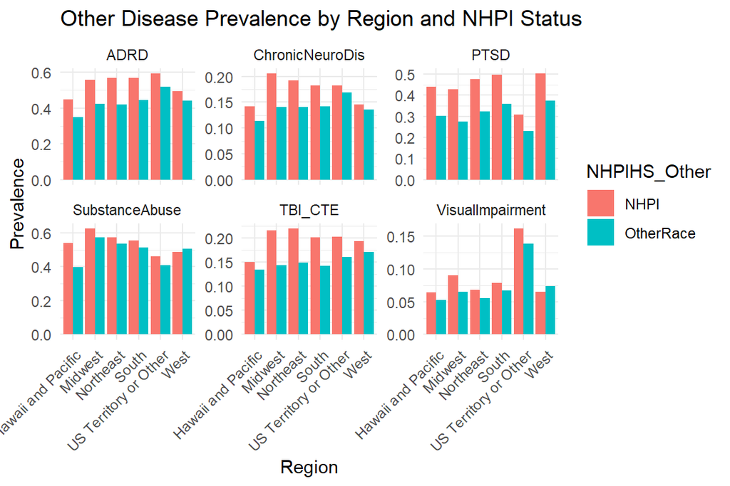

```r
load("P:/ORD_Raphael_202402042D/ChronicDisease/Fig_OtherCondByRegion2025Jun23.Rdata")
fig2_regionalOth
```

## 17 Adjusted Risk Models

Logistic regression analysis for NHPI versus Other Race Veterans adjusted for Age, Sex, Priority Group, and Geographic Region. NHPI are at elevated risk for Diabetes, CKD, Hypertension, CVD, Obesity, and Gout.

```r
load("P:/ORD_Raphael_202402042D/ChronicDisease/AdjustedModelsChr2025Jun23.Rdata")

results1 %>%
  gt() %>%
  fmt_number(columns = c(OR, CI_low, CI_high, p.value), decimals = 3) %>%
  cols_label(
    condition = "Condition",
    OR = "Odds Ratio",
    CI_low = "95% CI (Lower)",
    CI_high = "95% CI (Upper)",
    p.value = "P-value"
  ) %>%
  tab_header(title = "The Odds of Chronic Disease Outcomes for NHPI compared to non-NHPI")
```

The Odds of Chronic Disease Outcomes for NHPI compared to non-NHPI

| Condition | Odds Ratio | 95% CI (Lower) | 95% CI (Upper) | P-value |
| --- | --- | --- | --- | --- |
| Diabetes | 1.506 | 1.482 | 1.530 | 0.000 |
| Chronic Kidney Disease | 1.305 | 1.278 | 1.332 | 0.000 |
| Hypertension | 1.309 | 1.278 | 1.340 | 0.000 |
| Cardiovascular Disease | 1.217 | 1.196 | 1.238 | 0.000 |
| Obesity | 1.171 | 1.149 | 1.194 | 0.000 |
| Cancer | 0.960 | 0.936 | 0.985 | 0.002 |
| Gout | 1.697 | 1.660 | 1.735 | 0.000 |

## 18 More Adjusted Risk Models

```r
load("P:/ORD_Raphael_202402042D/ChronicDisease/AdjustedModelsOth2025Jun23.Rdata")

results2 %>%
  gt() %>%
  fmt_number(columns = c(OR, CI_low, CI_high, p.value), decimals = 3) %>%
  cols_label(
    condition = "Condition",
    OR = "Odds Ratio",
    CI_low = "95% CI (Lower)",
    CI_high = "95% CI (Upper)",
    p.value = "P-value"
  ) %>%
  tab_header(title = "The Odds of Disease Outcomes for NHPI compared to non-NHPI")
```

The Odds of Disease Outcomes for NHPI compared to non-NHPI

| Condition | Odds Ratio | 95% CI (Lower) | 95% CI (Upper) | P-value |
| --- | --- | --- | --- | --- |
| Substance Abuse | 1.156 | 1.139 | 1.173 | 0.000 |
| Visual Impairment | 1.238 | 1.204 | 1.273 | 0.000 |
| Post-traumatic stress disorder | 1.400 | 1.377 | 1.423 | 0.000 |
| TBI or CTE | 1.246 | 1.223 | 1.270 | 0.000 |
| Alzheimer's or Dementia | 1.344 | 1.324 | 1.364 | 0.000 |
| Cognitive Impairment | 1.428 | 1.404 | 1.453 | 0.000 |
| Chronic Neurological Disease | 1.281 | 1.256 | 1.307 | 0.000 |

## 19 Results

- NHPI Veterans are on average, younger, less male, disproportionately high disability, and more likely to reside in the Pacific and Western US region.
- NHPI veterans are shown to be at higher risk of many conditions when compared to non-NHPI veterans.
- NHPI have higher utilization of VA care than non-NHPI, but…
- NHPI much lower utilization of VA care when they live in the Pacific.
- NHPI in the Pacific also have lower or similar recorded rates of many conditions, but higher rates of Diabetes and Gout.

## 20 Conclusions

These findings are steps forward in the area of NHPI-specific veteran research, but they also just highlight how much there still is to do. This data shows there are hundreds of more focused disease-specific analyses that could shed more light on these disparities.

## 21 References

Kaholokula, J. K., R. A. Samoa, R. E. S. Miyamoto, N. Palafox, and S. A. Daniels. 2020. “COVID-19 Hits Native Hawaiian and Pacific Islander Communities the Hardest.” *Hawaii Journal of Health & Social Welfare* 79 (5): 144–46.

Look, M. A., M. K. Trask-Batti, M. L. Mau, and J. K. Kaholokula. 2013. “Assessment and Priorities for Health & Well-Being in Native Hawaiians & Other Pacific Peoples.” Honolulu, HI: Center for Native; Pacific Health Disparities Research.

Mau, M. K., K. Sinclair, E. P. Saito, K. N. Baumhofer, and J. K. Kaholokula. 2009. “Cardiometabolic Health Disparities in Native Hawaiians and Other Pacific Islanders.” *Epidemiologic Reviews* 31 (1): 113–29. https://doi.org/10.1093/epirev/mxp004.

Subica, A. M., N. Agarwal, J. G. Sullivan, and B. G. Link. 2019. “Obesity and Associated Health Disparities Among Understudied Multiracial, Pacific Islander, and American Indian Adults.” *Obesity* 27 (12): 2040–46. https://doi.org/10.1002/oby.22628.

Viernes, B., Q. Gan, Hanchrow E. E., M. Hu, G. Coronado, Duvall S. L., K. Raphael, and P. R. Alba. 2025. “Enhancing and Disaggregating Native Hawaiian and Pacific Islander (NHPI) Data Using Natural Language Processing and an Expanded Race/Ethnicity Lexicon.” *IOS Press*.